# Manufacturing Data Science 製造數據科學 - Assignment 2

### R10725013 陳志剛

# Q1 (20%)

# Q1-(a)試簡述何謂維度的詛咒？試列舉一案例說明

Ref : https://en.wikipedia.org/wiki/Curse_of_dimensionality

Ref : https://medium.com/flutter-community/curse-of-dimensionality-an-intuitive-and-practical-explanation-with-examples-399af3e38e70#:~:text=Example%202%3A,dimension%20they%20can%20move%20in.

根據維基百科，我們可以知道維度詛咒是一種"現象"，它會發生在維度過高的情況下。

簡單來說，當我們的維度過高，我們就需要更多額外的資料(保持密集性，而不會過於疏鬆)去進行訓練，才能確保模型的 robustness, reliability

舉例來說:

假設我們的目的是找到一隻小狗，當在「一維空間」中我們只要一直往前走就能輕易找到小狗；當在「二維空間」中因為小狗有更多空間可以分布，散亂在X、Y座標上，因此我們需要更多的資料才比較容找到小狗。當在「三維空間」小狗學會了飛翔，它在天空中亂飛，造成資料更加疏鬆(Sparse)，如果沒有足夠的資料量我們便更難保證(Robustness、Reliability)找的到小狗

# Q1-(b)避免維度詛咒的方法有哪些？

維度詛咒的問題就是維度太高，所以要避免維度詛咒的方法就是「降低維度」，常見的說法就是 Dimension Reduction，但我認為「Feature Selection」也算是一種方法。

以下列出幾個常見的方法:

PCA (Principal Component Analysis) :

LDA (Linear Discriminant Analysis)

Feature Selection by Information Gain

Feature Selection by Chi-square Test

# Q1-(c)試找一個開放數據 (e.g. Kaggle開放數據 或第一次作業紅酒數據集 )並選一種方法 (e.g. 線性迴歸或決策樹 )，用模擬方法 固定樣本數但逐步增加變數個數， 試著重新繪製圖 3.12， 呈現維度與預測 (或分類 )績效間的關係。

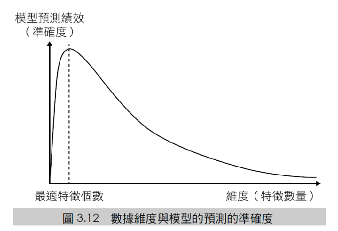

Ref dataset: https://www.kaggle.com/datasets/samuelcortinhas/credit-card-approval-clean-data?select=clean_dataset.csv

一個用來決定是否發信用卡的 Dataset

```python
import pandas as pd
import numpy as np
import matplotlib.pyplot as plt
import csv
from sklearn import linear_model
import statsmodels.api as sm
import seaborn as sns
from statsmodels.stats.stattools import durbin_watson
```

```python
path = "./Credit Card Approvals.csv"
df = pd.read_csv(path)
df = pd.get_dummies(df) # one-hot
df
```

|  | Gender | Age | Debt | Married | BankCustomer | YearsEmployed | PriorDefault | Employed | CreditScore | DriversLicense | ... | Industry_Transport | Industry_Utilities | Ethnicity_Asian | Ethnicity_Black | Ethnicity_Latino | Ethnicity_Other | Ethnicity_White | Citizen_ByBirth | Citizen_ByOtherMeans | Citizen_Temporary |
| --- | --- | --- | --- | --- | --- | --- | --- | --- | --- | --- | --- | --- | --- | --- | --- | --- | --- | --- | --- | --- | --- |
| 0 | 1 | 30.83 | 0.000 | 1 | 1 | 1.25 | 1 | 1 | 1 | 0 | ... | 0 | 0 | 0 | 0 | 0 | 0 | 1 | 1 | 0 | 0 |
| 1 | 0 | 58.67 | 4.460 | 1 | 1 | 3.04 | 1 | 1 | 6 | 0 | ... | 0 | 0 | 0 | 1 | 0 | 0 | 0 | 1 | 0 | 0 |
| 2 | 0 | 24.50 | 0.500 | 1 | 1 | 1.50 | 1 | 0 | 0 | 0 | ... | 0 | 0 | 0 | 1 | 0 | 0 | 0 | 1 | 0 | 0 |
| 3 | 1 | 27.83 | 1.540 | 1 | 1 | 3.75 | 1 | 1 | 5 | 1 | ... | 0 | 0 | 0 | 0 | 0 | 0 | 1 | 1 | 0 | 0 |
| 4 | 1 | 20.17 | 5.625 | 1 | 1 | 1.71 | 1 | 0 | 0 | 0 | ... | 0 | 0 | 0 | 0 | 0 | 0 | 1 | 0 | 1 | 0 |
| ... | ... | ... | ... | ... | ... | ... | ... | ... | ... | ... | ... | ... | ... | ... | ... | ... | ... | ... | ... | ... | ... |
| 685 | 1 | 21.08 | 10.085 | 0 | 0 | 1.25 | 0 | 0 | 0 | 0 | ... | 0 | 0 | 0 | 1 | 0 | 0 | 0 | 1 | 0 | 0 |
| 686 | 0 | 22.67 | 0.750 | 1 | 1 | 2.00 | 0 | 1 | 2 | 1 | ... | 0 | 0 | 0 | 0 | 0 | 0 | 1 | 1 | 0 | 0 |
| 687 | 0 | 25.25 | 13.500 | 0 | 0 | 2.00 | 0 | 1 | 1 | 1 | ... | 0 | 0 | 0 | 0 | 1 | 0 | 0 | 1 | 0 | 0 |
| 688 | 1 | 17.92 | 0.205 | 1 | 1 | 0.04 | 0 | 0 | 0 | 0 | ... | 0 | 0 | 0 | 0 | 0 | 0 | 1 | 1 | 0 | 0 |
| 689 | 1 | 35.00 | 3.375 | 1 | 1 | 8.29 | 0 | 0 | 0 | 1 | ... | 0 | 0 | 0 | 1 | 0 | 0 | 0 | 1 | 0 | 0 |

690 rows × 35 columns

```python
# Statistic
x = df.drop(["Approved"], axis=1)
y = df["Approved"]
# y = df.iloc[:,-1]
# print(x)
# print(y)
s_x = sm.add_constant(x)
model = sm.OLS(y, s_x).fit()
print(model.summary())
```

```
                            OLS Regression Results
==============================================================================
Dep. Variable:               Approved   R-squared:                       0.610
Model:                            OLS   Adj. R-squared:                  0.591
Method:                 Least Squares   F-statistic:                     33.14
Date:                Fri, 21 Oct 2022   Prob (F-statistic):          4.31e-113
Time:                        02:35:37   Log-Likelihood:                -172.11
No. Observations:                 690   AIC:                             408.2
Df Residuals:                     658   BIC:                             553.4
Df Model:                          31
Covariance Type:            nonrobust
==================================================================================================
                                     coef    std err          t      P>|t|      [0.025      0.975]
--------------------------------------------------------------------------------------------------
const                              0.1295      0.045      2.865      0.004       0.041       0.218
Gender                            -0.0060      0.028     -0.211      0.833      -0.062       0.050
Age                                0.0007      0.001      0.563      0.573      -0.002       0.003
Debt                              -0.0024      0.003     -0.872      0.384      -0.008       0.003
Married                           -0.4206      0.289     -1.455      0.146      -0.988       0.147
BankCustomer                       0.4830      0.290      1.663      0.097      -0.087       1.053
YearsEmployed                      0.0060      0.004      1.351      0.177      -0.003       0.015
PriorDefault                       0.5765      0.030     18.942      0.000       0.517       0.636
Employed                           0.1238      0.033      3.747      0.000       0.059       0.189
CreditScore                        0.0075      0.003      2.301      0.022       0.001       0.014
DriversLicense                    -0.0263      0.026     -1.031      0.303      -0.076       0.024
ZipCode                           -0.0002   7.55e-05     -2.670      0.008      -0.000   -5.33e-05
Income                          7.127e-06   3.05e-06      2.333      0.020    1.13e-06    1.31e-05
Industry_CommunicationServices     0.0183      0.059      0.312      0.755      -0.097       0.133
Industry_ConsumerDiscretionary    -0.0133      0.054     -0.246      0.806      -0.119       0.093
Industry_ConsumerStaples          -0.0399      0.051     -0.777      0.438      -0.141       0.061
Industry_Education                 0.0285      0.073      0.389      0.698      -0.115       0.172
Industry_Energy                    0.0299      0.038      0.787      0.431      -0.045       0.105
Industry_Financials               -0.0340      0.049     -0.689      0.491      -0.131       0.063
Industry_Healthcare               -0.3143      0.142     -2.215      0.027      -0.593      -0.036
Industry_Industrials               0.0847      0.048      1.751      0.080      -0.010       0.180
Industry_InformationTechnology     0.1316      0.055      2.374      0.018       0.023       0.240
Industry_Materials                 0.0579      0.046      1.257      0.209      -0.032       0.148
Industry_Real Estate              -0.0128      0.063     -0.204      0.838      -0.136       0.110
Industry_Research                 -0.0885      0.113     -0.785      0.433      -0.310       0.133
Industry_Transport                 0.0596      0.181      0.330      0.742      -0.295       0.415
Industry_Utilities                 0.2217      0.058      3.829      0.000       0.108       0.335
Ethnicity_Asian                   -0.0534      0.057     -0.930      0.353      -0.166       0.059
Ethnicity_Black                    0.0073      0.045      0.162      0.871      -0.081       0.096
Ethnicity_Latino                   0.1575      0.123      1.276      0.202      -0.085       0.400
Ethnicity_Other                    0.0414      0.072      0.577      0.564      -0.099       0.182
Ethnicity_White                   -0.0234      0.042     -0.556      0.579      -0.106       0.059
Citizen_ByBirth                   -0.0964      0.038     -2.551      0.011      -0.171      -0.022
Citizen_ByOtherMeans              -0.1001      0.047     -2.129      0.034      -0.192      -0.008
Citizen_Temporary                  0.3259      0.093      3.507      0.000       0.143       0.508
==============================================================================
Omnibus:                       38.065   Durbin-Watson:                   0.611
Prob(Omnibus):                  0.000   Jarque-Bera (JB):               90.830
Skew:                          -0.281   Prob(JB):                     1.89e-20
Kurtosis:                       4.687   Cond. No.                     3.17e+16
==============================================================================

Notes:
[1] Standard Errors assume that the covariance matrix of the errors is correctly specified.
[2] The smallest eigenvalue is 1.94e-23. This might indicate that there are
strong multicollinearity problems or that the design matrix is singular.
```

```python
# Sort the p-value
p_values = model.pvalues
sort_p = p_values.sort_values(ascending=True)
print(sort_p)
ranked_attr = sort_p.index[0:].drop(["const"])
print(len(ranked_attr), ranked_attr)
```

```
PriorDefault                      3.426319e-64
Industry_Utilities                1.406850e-04
Employed                          1.946839e-04
Citizen_Temporary                 4.838295e-04
const                             4.306510e-03
ZipCode                           7.776959e-03
Citizen_ByBirth                   1.095274e-02
Industry_InformationTechnology    1.788670e-02
Income                            1.992583e-02
CreditScore                       2.167642e-02
Industry_Healthcare               2.708149e-02
Citizen_ByOtherMeans              3.359091e-02
Industry_Industrials              8.047165e-02
BankCustomer                      9.670034e-02
Married                           1.460806e-01
YearsEmployed                     1.772441e-01
Ethnicity_Latino                  2.023707e-01
Industry_Materials                2.090321e-01
DriversLicense                    3.029904e-01
Ethnicity_Asian                   3.527727e-01
Debt                              3.836302e-01
Industry_Energy                   4.314213e-01
Industry_Research                 4.328649e-01
Industry_ConsumerStaples          4.375770e-01
Industry_Financials               4.908521e-01
Ethnicity_Other                   5.640051e-01
Age                               5.734489e-01
Ethnicity_White                   5.786929e-01
Industry_Education                6.977229e-01
Industry_Transport                7.417429e-01
Industry_CommunicationServices    7.549544e-01
Industry_ConsumerDiscretionary    8.060667e-01
Gender                            8.326607e-01
Industry_Real Estate              8.380482e-01
Ethnicity_Black                   8.710588e-01
dtype: float64
34 Index(['PriorDefault', 'Industry_Utilities', 'Employed', 'Citizen_Temporary',
       'ZipCode', 'Citizen_ByBirth', 'Industry_InformationTechnology',
       'Income', 'CreditScore', 'Industry_Healthcare', 'Citizen_ByOtherMeans',
       'Industry_Industrials', 'BankCustomer', 'Married', 'YearsEmployed',
       'Ethnicity_Latino', 'Industry_Materials', 'DriversLicense',
       'Ethnicity_Asian', 'Debt', 'Industry_Energy', 'Industry_Research',
       'Industry_ConsumerStaples', 'Industry_Financials', 'Ethnicity_Other',
       'Age', 'Ethnicity_White', 'Industry_Education', 'Industry_Transport',
       'Industry_CommunicationServices', 'Industry_ConsumerDiscretionary',
       'Gender', 'Industry_Real Estate', 'Ethnicity_Black'],
      dtype='object')
```

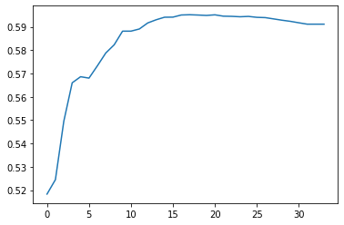

```python
# Statistic
rsquared_adj_list = []
y = df["Approved"]
for i in range(len(ranked_attr)):
  x = df.iloc[:,][ranked_attr[0:i+1]]
  # print(x)
  s_x = sm.add_constant(x)
  model2 = sm.OLS(y, s_x).fit()
  # print(model2.rsquared_adj)
  rsquared_adj_list.append(model2.rsquared_adj)
plt.plot(rsquared_adj_list)
```

由上圖可知，最佳的 Feature 個數約在 20 左右，20 開始有緩慢下降，但未如範例中下降的如此快速

因此可以推論，此資料集的 Feature 量適中，未達到明顯的維度詛咒現象

# Q2 (20%)

# Q2-(a)試找一個開放數據 (e.g. Kaggle開放數據 )，您會用什麼方法來確認資料品質的好壞?試操作一次並說明其細節

這個階段，我主要會使用於(c)小題所提出的 3 個 KPI 來檢驗資料品質，分別是

Missing value rate : 檢驗有多少比例的缺失資料，因為過多的遺失資料可能造成訓練結果不佳

Class ratio : 檢驗預測類別的比例，查看是否有不平衡(data imbalance)的狀態

Entropy : 檢驗 Data 是否有足夠的資訊量(變異)來進行學習，若 Data 完全沒有資訊量(變異)便無法學到有價值的東西

參考資料集 : https://www.kaggle.com/datasets/rikdifos/credit-card-approval-prediction

- 這是一個用來評量信用卡風險等級的資料集，label為逾期多久未繳卡費(Ex: 0: 1-29 days past due 1: 30-59 days past due 2: 60-89 days overdue 3: 90-119 days overdue 4: 120-149 days overdue 5: Overdue or bad debts, write-offs for more than 150 days C: paid off that month X: No loan for the month)

## For Missing value rate : 檢驗有多少比例的缺失資料，因為過多的遺失資料可能造成訓練結果不佳

```python
feature_path = "./application_record.csv"
df_feature = pd.read_csv(feature_path)
df_feature.isnull().sum()
```

```
ID                          0
CODE_GENDER                 0
FLAG_OWN_CAR                0
FLAG_OWN_REALTY             0
CNT_CHILDREN                0
AMT_INCOME_TOTAL            0
NAME_INCOME_TYPE            0
NAME_EDUCATION_TYPE         0
NAME_FAMILY_STATUS          0
NAME_HOUSING_TYPE           0
DAYS_BIRTH                  0
DAYS_EMPLOYED               0
FLAG_MOBIL                  0
FLAG_WORK_PHONE             0
FLAG_PHONE                  0
FLAG_EMAIL                  0
OCCUPATION_TYPE        134203
CNT_FAM_MEMBERS             0
dtype: int64
```

```python
print("OCCUPATION_TYPE 缺失比例:", 134203/len(df_feature))
```

```
OCCUPATION_TYPE 缺失比例: 0.30601039317580153
```

由上面的統計數據可知，有關職位類別(Ex:勞工、會計師、銷售員)的 Feature 缺失約 30 % 的數據，其他 Feature 皆無缺失。

這裡我們可以做兩種實驗:

1. 因為 OCCUPATION_TYPE 缺失的比例有點過高，暫時剔除這個欄位來進行訓練
2. 根據經驗 OCCUPATION_TYPE 可能對於信用卡評級十分重要，因此只抓出擁有此欄位的資料來進行訓練，畢竟此資料集十分龐大(439K)，即使缺失30%仍有足夠的資料量進行訓練

```python
label_path = "./credit_record.csv"
df_label = pd.read_csv(label_path)["STATUS"]
df_label.isnull().sum()
```

```
0
```

由此可知 labels 的部分沒有 missing value

## Class ratio : 檢驗預測類別的比例，查看是否有不平衡(data imbalance)的狀態，不平衡的 label 可能造成模型預設偏向數量多的那一邊 (因為這樣準確度就夠高了)

```python
df_label.value_counts()
```

```
C    442031
0    383120
X    209230
1     11090
5      1693
2       868
3       320
4       223
Name: STATUS, dtype: int64
```

```python
total_nums = df_label.value_counts().sum()

for label, num in zip(df_label.value_counts().index,df_label.value_counts()):
  print(label,"ratio:", num/total_nums*100, "%")
```

```
C ratio: 42.1554013780607 %
0 ratio: 36.537205254750496 %
X ratio: 19.95374675154376 %
1 ratio: 1.0576258255251174 %
5 ratio: 0.161457215745178 %
2 ratio: 0.0827790096082779 %
3 ratio: 0.030517607228858212 %
4 ratio: 0.021266957537610567 %
```

Hint: (0: 1-29 days past due 1: 30-59 days past due 2: 60-89 days overdue 3: 90-119 days overdue 4: 120-149 days overdue 5: Overdue or bad debts, write-offs for more than 150 days C: paid off that month X: No loan for the month))

由此可見 Data labels 的分布不均，主要集中在 C、O、X三種類別。

因此我認為可以將1~5以及X合併成一個類別稱作 "Other" 這樣既可以符合現實的用途，又可以減少資料不平均的狀況。

(合併後會變成約: 42 : 36 : 22)，較無過度的不平均

## Entropy : 檢驗 Data 是否有足夠的資訊量(變異)來進行學習，若 Data 完全沒有資訊量(變異)便無法學到有價值的東西

```python
# Ref: https://stackoverflow.com/questions/15450192/fastest-way-to-compute-entropy-in-python
from math import log, e
def entropy(labels, base=None):
  vc = pd.Series(labels).value_counts(normalize=True, sort=False)
  base = e if base is None else base
  return -(vc * np.log(vc)/np.log(base)).sum()

for col in df_feature.columns[1:]:
  print(col, "entropy:", entropy(df_feature[col]))
```

```
CODE_GENDER entropy: 0.633194421927606
FLAG_OWN_CAR entropy: 0.6599575433808914
FLAG_OWN_REALTY entropy: 0.6163930416252954
CNT_CHILDREN entropy: 0.8600196487285733
AMT_INCOME_TOTAL entropy: 3.5520889913807916
NAME_INCOME_TYPE entropy: 1.1885802691753427
NAME_EDUCATION_TYPE entropy: 0.7731105040759515
NAME_FAMILY_STATUS entropy: 1.0399550935372894
NAME_HOUSING_TYPE entropy: 0.46465335669943153
DAYS_BIRTH entropy: 9.503890104715765
DAYS_EMPLOYED entropy: 7.61629298091829
FLAG_MOBIL entropy: -0.0
FLAG_WORK_PHONE entropy: 0.5087876950138959
FLAG_PHONE entropy: 0.6001438160016807
FLAG_EMAIL entropy: 0.34275044180097686
OCCUPATION_TYPE entropy: 2.27581664532134
CNT_FAM_MEMBERS entropy: 1.229814269614912
```

由此可以每個 Label 多多少少都有資訊量存在，可以進行訓練，只有 FLAG_MOBIL 的資訊量為0，因此可以去除這個 Feature 進行訓練。

更進一步我們也可以依照資訊量的多寡進行排名，來挑選訓練用的 Feature

# Q2-(b)公司 或您 是否有現存方法來進行資料品質的確認？如果有(或沒有 )，試依您的角度說明(或建議)確認資料品質的標準作業流程 (i.e. SOP)。

Ref: 教科書PPT(P49)

1. 數據來源與時效 (• 數據占比性 Proportion • 數據及時性 Timeliness • 數據存取 Accessibility)
2. 數據一致與格式 (• 數據一致性 Consistency • 數據唯一性 Uniqueness • 數據多元性 diversity • 數據動態性 dynamicity)
3. 資訊安全 (• 數據機密性 Confidentiality • 數據完整性 Integrity • 數據可用性 Availability)
4. 數據準確與完善 (• 數據準確性 Accuracy • 數據驗證性 Validity • 數據完善性 Completeness • 數據解釋性 interpretability)

# Q2-(c)試建議三個可能衡量數據品質的量化指標 (i.e. KPIs)。

Missing value rate : 檢驗有多少比例的缺失資料，因為過多的遺失資料可能造成訓練結果不佳

Class ratio : 檢驗預測類別的比例，查看是否有不平衡(data imbalance)的狀態。若 data 過於偏向某一類別，Classifier 的分類結果也容易偏向那一類別 (因為全部預測同一類別的分數可能就很高的)

Entropy : 檢驗 Data 是否有足夠的資訊量(變異)來進行學習

# Q3 (20%) 在數據科學分析架構中的決策支援階段

# Q3-(a)什麼是模型的適應性與擴充性?

### Ref: 教科書PPT(P35~36)

### 適應性 :

如字面上的意思，適應性代表模型能夠適應不同環境的能力，也就是說模型在不同的情境下，都能保持一定的預測能力。最常被討論到的就是時間、空間上的適應性。

舉例來說，模型的預測能力，是否會隨著時間下降?還是能適應這個時間的變化?這也就衍伸出了概念飄移，發現某些現象後就 re-train model，讓模型能夠適應時間。

### 擴充性 :

擴充性指的是訓練完的一個模型，是否可以將這個模型擴充到其他應用上?

舉例來說，最常聽到的應該就是 Transfer learning 了，我訓練完 A 模型(Ex: 分類100種圖片類別)之後，可以將它的參數保留下來，拿去給 B 模型(Ex: 分類貓、狗等動物)進行訓練，用來分類不同的問題。

假如以製造現場來說，就是我給 A 機台用的模型，能否擴充到 B 機台上使用

# Q3-(b)在AI專案中(可根據第一題的開放數據與模型)，就您所使用的數據與建構預測模型是否具備適應性與擴充性?為什麼?該如何改善與調整?

### For 適應性

因為我的資料集為「是否核發信用卡」所以我覺得它的適用性會隨著經濟狀況有很大的改變。

舉例來說: 當經濟平穩(不論上升、下降)，沒有戰爭、疫情，此模型的適用性就會不錯，但只要戰爭、疫情頻起，金融風暴來襲，此時就需要調整模型以適應當前的環境

所以調整方式因加入的一評估「經濟狀態」的變量，讓我們得知當前情勢是否需要大幅的重新訓練模型。

### For 擴充性

我覺得此數據的擴充性不錯，因為從各 Feature (如房產、職業、婚姻) 可得知一個人大致上的經濟狀況，這不只可以用來核發信用卡，也可以用來作為投資建議的依據。

我認為信用卡公司能將這個數據擴充至保險業務的推銷上，重新訓練一個保險推銷的模型應是一個不錯的應用。但是仍有一個改善空間，就是「客戶的風險傾向」，投資這一領域十分看重客戶的習性，若能新增這一特徵應能讓準確度更高。

# Q4 (10%) 遺漏值填補的方法包括了統計量填補 、預測式與生成式填補

# Q4-(a)試說明這些方法分別適用於什麼樣情形

### 統計量填補

- 顧名思義，我們會用統計的方式計算出一個數值來填補 missing value，最常見的如平均值、中位數、眾數
- 當我們想快速地填補 missing value 時，這是一個最快速的手段

### 預測式填補 (Ref:https://jmlr.org/papers/v18/17-073.html)

- 簡單來說我們會先用現有訓練一個模型，再用此模型來預測這些 missing value。此篇論文有提到常見的方式如K -nearest neighbors, support vector machines, and decision tree 。
- 如果我們希望填補的 missing value 與 dataset 中的其他資料有一定的關聯，可以用此方法來填補資料

### 生成式填補 (Ref:https://arxiv.org/abs/1806.02920)

- 這是一個 GAN(Generative adversarial networks) 的應用手法，我們會訓練 GAN 的 generator 來產生資料，訓練 discriminator 來判別資料的真假；當此 generator 訓練到 discriminator 難以判別時，此生成的資料便會與真實資料十分相似，因此可以用GAN產生的資料來填補 missing data
- 如果時間足夠，算力足夠，這應該是最有可能填補出接近真實資料的方法

# Q4-(b)為什麼某特徵存在大量遺漏值不宜直接刪除？

如果出現所謂的"大量"遺漏，這本身其實就是一個重要的資訊，而此特徵也可能幫助我們發現一些異常狀態。

舉例來說 :

假設工廠中紀錄濕度的100台機器中只有1台正常運行，因此我們的 dataset 中就只有 1% 的溼度資料被完整記錄，這時如果我們去分析此特徵大量遺漏的原因，就能發現原來是濕度相關的機器大量故障所導致，應該維修機器而不是刪除此特徵。

# Q5 (30%) 在 UCI Machine Learning Repository開 放 數據中包含了一個鋼板缺陷數據 (steel plates faults dataset https://archive.ics.uci.edu/ml/datasets/steel+plates+faults) 一共包含了1,941個觀測值，而每個觀測值具有 27個特徵以及作為目標值的7種缺陷。試挑選出凹凸不平(Bumps)以及刮痕(K_Scratch)兩種缺陷進行分析

# Q5-(1)試將羅吉斯迴歸分析的結果呈現如下表，並試著解釋任一特徵與目標值之間的關係。

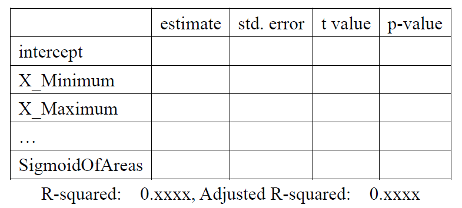

Ref: https://michael-fuchs-python.netlify.app/2019/11/15/multinomial-logistic-regression/

```python
path = "./MDS_Assignment2_Steelplates.xlsx"

### Get columns name ###
df1 = pd.read_excel(path, sheet_name="Var_Name", header=None)
# print(df1)
col_names = df1.values # ndarray
col_names_list = []
for name in col_names:
  # print(name, type(name), name[0], type(name[0]))
  col_names_list.append(name[0])

### complete the dataset ###
df2 = pd.read_excel(path, sheet_name="Faults", header=None)
df2.columns = col_names_list

filter = (df2["K_Scatch"] == 1) | (df2["Bumps"] == 1) # 只取出指定的兩種 label 做分析
df2 = df2.loc[filter]
# filter2 =
# print(filter)
# df2_K_Scatch = df2.loc[filter1]
# df2_Bumps = df2.loc[filter2]


x_train = df2.iloc[:, 0:27]
y_train = df2[["K_Scatch", "Bumps"]]

### Some experient ###
# y_train_K_Scatch = df2[["K_Scatch"]]
# y_train_Bumps = df2[["Bumps"]]
# print(y_train)

# labels = []
# for v in y_train.values:
#   if(v[0] == 1):
#     labels.append(1)
#   else:
#     labels.append(0)
# y_train["labels"] = labels

# print(y_train)
# y_index_dict = {}
# for i,cls in enumerate(y_train):
#   y_index_dict[i] = cls
# # print(y_index_dict)

# labels = []
# for i in y_train.values:
#   index = np.where(i == 1)[0][0]
#   # print(y_index_dict[index])
#   labels.append(y_index_dict[index])

# y = pd.DataFrame(labels, columns=["labels"])
# print(y)
```

```python
s_x = sm.add_constant(x_train)
model = sm.MNLogit(y_train, s_x).fit()
print(model.summary())
```

```
Warning: Maximum number of iterations has been exceeded.
         Current function value: 0.027633
         Iterations: 35
                          MNLogit Regression Results
==============================================================================
Dep. Variable:                      y   No. Observations:                  793
Model:                        MNLogit   Df Residuals:                      766
Method:                           MLE   Df Model:                           26
Date:                Fri, 14 Oct 2022   Pseudo R-squ.:                  0.9601
Time:                        06:55:26   Log-Likelihood:                -21.913
converged:                      False   LL-Null:                       -549.59
Covariance Type:            nonrobust   LLR p-value:                6.779e-206
=========================================================================================
              y=Bumps       coef    std err          z      P>|z|      [0.025      0.975]
-----------------------------------------------------------------------------------------
const                   -74.8902        nan        nan        nan         nan         nan
X_Minimum                -0.4319      0.452     -0.956      0.339      -1.317       0.454
X_Maximum                 0.4328      0.452      0.958      0.338      -0.452       1.318
Y_Minimum                -0.0328      0.223     -0.147      0.883      -0.470       0.404
Y_Maximum                 0.0328      0.223      0.147      0.883      -0.404       0.470
Pixels_Areas             -0.0331      0.014     -2.395      0.017      -0.060      -0.006
X_Perimeter              -0.1403      0.080     -1.758      0.079      -0.297       0.016
Y_Perimeter               0.1679      0.123      1.365      0.172      -0.073       0.409
Sum_of_Luminosity         0.0002      0.000      2.134      0.033    1.92e-05       0.000
Minimum_of_Luminosity     0.3006      0.113      2.659      0.008       0.079       0.522
Maximum_of_Luminosity     0.4938      0.233      2.120      0.034       0.037       0.950
Length_of_Conveyer       -0.0075      0.012     -0.635      0.525      -0.031       0.016
TypeOfSteel_A300        -36.6065        nan        nan        nan         nan         nan
TypeOfSteel_A400        -38.3030        nan        nan        nan         nan         nan
Steel_Plate_Thickness     0.2008      0.105      1.913      0.056      -0.005       0.407
Edges_Index              11.9702      4.034      2.967      0.003       4.064      19.876
Empty_Index              63.9994     37.066      1.727      0.084      -8.648     136.647
Square_Index             -0.5897      3.753     -0.157      0.875      -7.945       6.765
Outside_X_Index        -326.9234    533.860     -0.612      0.540   -1373.271     719.424
Edges_X_Index           -24.2797      8.731     -2.781      0.005     -41.391      -7.168
Edges_Y_Index            20.8292      8.585      2.426      0.015       4.004      37.655
Outside_Global_Index     -5.0279      3.289     -1.529      0.126     -11.475       1.419
LogOfAreas               77.5769     47.539      1.632      0.103     -15.598     170.752
Log_X_Index             -43.5456     52.003     -0.837      0.402    -145.469      58.378
Log_Y_Index            -111.1250     55.939     -1.987      0.047    -220.763      -1.487
Orientation_Index        21.3377     14.855      1.436      0.151      -7.778      50.454
Luminosity_Index       -120.0497     45.643     -2.630      0.009    -209.509     -30.590
SigmoidOfAreas           -5.9786      6.415     -0.932      0.351     -18.552       6.595
=========================================================================================
```

Ref: https://statisticsbyjim.com/regression/interpret-coefficients-p-values-regression/

簡單來說，在其他變數不動的情況下，Outside_X_Index增加一個單位，會使得預測值大量的向 0 靠攏，也就是預測結果會偏向"K_Scatch"。(在此0 = K_Scatch, 1 = Bumps)

這是可預期的，因為當外圈的 X 越大就越容易造成刮痕(Scratch)

# Q5-(2) 基於上述(a)的 結果，將上述特徵以t-value進行排序後，哪些特徵的迴 歸係數在統計上是顯著的呢(p-value<0.01)?

['Edges_Index', 'Edges_X_Index', 'Minimum_of_Luminosity', 'Luminosity_Index'] 在統計上是顯著的(p-value<0.01)

```python
p_values = model.pvalues

sort_p = p_values.sort_values(by=0)
print(sort_p)

sig_var = []
for index, value in zip(sort_p.index, sort_p.values):
  # print(index, value[0])
  if(value[0] < 0.01):
    sig_var.append(index)

print("Significant variables with p values<0.01 : ", sig_var)
```

```
                              0
Edges_Index            0.003003
Edges_X_Index          0.005419
Minimum_of_Luminosity  0.007830
Luminosity_Index       0.008534
Edges_Y_Index          0.015253
Pixels_Areas           0.016610
Sum_of_Luminosity      0.032882
Maximum_of_Luminosity  0.033990
Log_Y_Index            0.046973
Steel_Plate_Thickness  0.055770
X_Perimeter            0.078763
Empty_Index            0.084231
LogOfAreas             0.102712
Outside_Global_Index   0.126372
Orientation_Index      0.150900
Y_Perimeter            0.172386
X_Maximum              0.337827
X_Minimum              0.339058
SigmoidOfAreas         0.351368
Log_X_Index            0.402384
Length_of_Conveyer     0.525328
Outside_X_Index        0.540289
Square_Index           0.875123
Y_Maximum              0.883041
Y_Minimum              0.883044
const                       NaN
TypeOfSteel_A300            NaN
TypeOfSteel_A400            NaN
Significant variables with p values<0.01 :  ['Edges_Index', 'Edges_X_Index', 'Minimum_of_Luminosity', 'Luminosity_Index']
```

# Q5-(3) 試問配適一個羅吉斯迴歸模型是否合適？試若配適不佳，試說明其可能的原因為何？

若單從 Pseudo R-squ = 0.9601 來看，此羅吉斯模型的表現不錯；但是我們可以注意到 coef 的部分有強烈的負相關傾向(-326, -120, -111......)，這代表此模型其實不怎麼穩定，容易因為這些變數而造成分類錯誤。

造成這種現象的原因，可能是因為這些擁有強烈負相關的特徵，他們得label有絕大部分都屬於「0」這個類別，導致當看到這個特徵值時，模型就傾向將他分類成「0」。

# Q5-(4)試問配適一個線性判別分析模型是否合適？若配適不佳，試說明其可能的原因為何？

線性判別分析模型有可能比較合適，尤其是在 muticlass 的問題中會更明顯，因為在 multiclass 的問題中羅吉斯回歸模型找尋邊界會有順序性的問題，不同順序的結果可能大不相同。

但線性判別分析模型仍可能配適不佳，主要是因為他有一個強假設「特徵近似於常態分布」，當特徵與常態分佈差異太大時，容易造成偏誤

Ref: 教科書PPT(P29)

# Q5-(5)試問配適一個二次判別分析模型是否合適？若配適不佳，試說明其可能的原因為何？

有可能較為合適，若兩個變數分布的方向性不同時就較為合適，如圖(教科書P49)

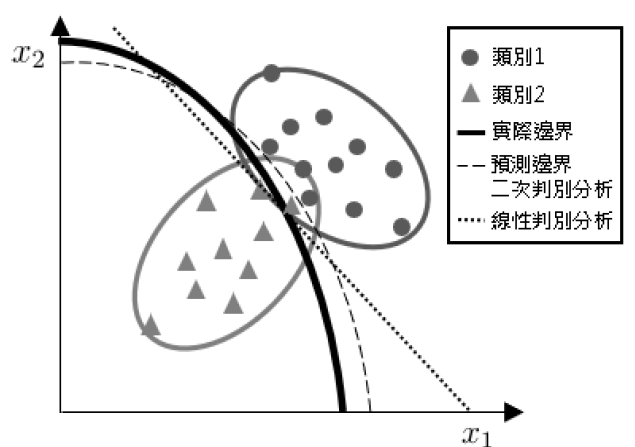

這其實是由於兩個變數的不等變異造成的結果。由此可知，當變數的不等變異使之分布的方向性一致時，二次判別分析可能就較不合適。

Ref: 教科書PPT(P49~50)